# Power analysis

```r
#install.packages("tidystats")
library(stringr)
library(dplyr)
```

```r
library(ggplot2)
library(rstatix)
load("~/Dropbox (University of Oregon)/UO-SAN Lab/Berkman Lab/Devaluation/analysis_files/data/scored_data_w_demographics.RData")
scored<-scored_with_demographics
rm(scored_with_demographics)
scored$score <- as.numeric(scored$score)
scored$scale_name <- sub("-","_",scored$scale_name)
```

```r
#
scored %>% filter(scale_name %in% c("FCI")) %>% select(scored_scale) %>% unique
```

|  | scored_scale |
| --- | --- |
| 10751 | cancer_preventing |
| 10952 | cancer_promoting |
| 11153 | craved_cancer_preventing |
| 11354 | craved_cancer_promoting |
| 11555 | dairy |
| 11756 | empty_calories |
| 11957 | fried_food |
| 12158 | fruit |
| 12359 | grains |
| 12560 | liked_cancer_preventing |

[output cut: 7 more lines]

```r
scored$scale_name %>% unique
```

```
##  [1] "MESA"   "FTND"   "BFI"    "BSCS"   "NCS"    "PLAN"   "SRHI"   "TESQ_E"
##  [9] "TRSQ"   "BIS_11" "cSES"   "EDM"    "FCI"    "FFQ"    "PCS"    "RMQ"
## [17] "RS"     "RTFS"   "ACES"   "IMI"    "DEMO"
```

```r
load("../../../files/data/ppt_list_w_data.RData")
#our primary health outcome measure
ppt_health_outcomes <- ppt_list_w_data %>% select(dev_id,bf_1) %>% filter(!is.na(bf_1))
rm(ppt_list_w_data)
```

## Health measures include:

- Percent Body Fat (`bf_1`)
- BMI (`bmi_0`)

## Behavioral outcome measures

We also have behavioral outcome measures:

- Food Frequency Questionnaire. Very closely related to the Food Craving Inventory so that needs to be considered carefully.

## Self-report predictor variables to investigate

Which predictor scales should we include?

Need the behavioral and self-report imho

Before we decide which to include, perhaps we put them into categories: obvious theoretical link to outcome (3), possible theoretical link to outcome (2), no clear theoretical link to outcome (1).

Listing them by these categories we get:

### Obvious theoretical link to outcome

These are explicitly designed to measure constructs we are concerned about, like self control or habits.

- Brief Self Control Scale
- Self-reported Habit Index
- Tempest Self-Regulation Questionnaire for Eating
- Treatment Self-Regulation Questionnaire
- Barratt Impulsiveness Scale
- Eating Dysregulation Measure
- Food Craving Inventory
- Restraint Scale

### Possible theoretical link to outcome

These aren’t explicitly designed to measure constructs we are concerned about, but there are theoretical reasons or at least ‘stories you could tell’ to expect a link to outcome.

- Big Five
- Planfulness
- Regulatory Mode Questionnaire
- Responses to Failure Scale
- Perceived Competence Scale

### No clear theoretical link to outcome

For this category it is unclear why we would expect any link to the outcome (eating). Some are included in DEV more because of their theoretical link to the treatment rather than to baseline level of obesity.

- Need for Cognition Scale
- Vividness of Visual Imagery Questionnaire
- Intrinsic Motivation Inventory
- Adverse Childhood Experiences

### In DEV but not a construct of interest

These are in DEV but aren’t psychological constructs and so I’m not considering them.

- International Physical Activity Questionnaire
- Demographic measures

## Behavioral predictor variables

- WTP
  - price given for healthy foods
  - price given for unhealthy foods
  - difference between the above two
- ROC
  - [regulate - look] craving reduction for healthy foods
  - [regulate - look] craving reduction for unhealthy foods
  - balance of the above two
- SST
  - Participant behavioral net response bias toward healthy foods
  - Participant behavioral net response bias toward unhealthy foods
  - difference between the above

# Checking for presence of each of these

Do we have these scales? let’s take a look.

```r
table(scored$scale_name)
```

```
##
##   ACES    BFI BIS_11   BSCS   cSES   DEMO    EDM    FCI    FFQ   FTND    IMI
##    800   1224   1608    631    201   3316    201  10676   8792    212    800
##   MESA    NCS    PCS   PLAN    RMQ     RS   RTFS   SRHI TESQ_E   TRSQ
##    164   3876    628    816    603    201   1256    612   4417    631
```

Group 1:

## the following were NOT pre-registered.

Group 2:

These aren’t explicitly designed to measure constructs we are concerned about, but there are theoretical reasons or at least ‘stories you could tell’ to expect a link to outcome.

## analysis (left over from previous analysis)

Get the first survey for each scale:

```r
scored$survey_num <- as.numeric(str_trim(str_match(scored$survey_name,"[DEV Session \\s][\\d+][\\sSurveys]")))
first_survey_for_scale<-scored %>% group_by(scale_name) %>% dplyr::summarise("first_survey"=min(survey_num))

#then select it.
scored_fs <- scored %>%
  merge(first_survey_for_scale,by="scale_name") %>%
  filter(survey_num==first_survey)

print("survey used for each scale:")
```

```
## [1] "survey used for each scale:"
```

```r
print(first_survey_for_scale)
```

```
## # A tibble: 21 × 2
##    scale_name first_survey
##    <chr>             <dbl>
##  1 ACES                  2
##  2 BFI                   0
##  3 BIS_11                1
##  4 BSCS                  0
##  5 cSES                  1
##  6 DEMO                  0
##  7 EDM                   1
##  8 FCI                   1
##  9 FFQ                   1
## 10 FTND                  0
## # … with 11 more rows
```

```r
sapply(unique(scored_fs$scale_name),function(sn){list(sn=unique(scored_fs[scored_fs$scale_name==sn,"scored_scale"]))})
```

```
## $ACES.sn
## [1] "sum"                   "neglectful_parenting"  "household_dysfunction"
## [4] "abuse"                 "divorced_separated"
##
## $BFI.sn
## [1] "agreeableness"     "conscientiousness" "extraversion"
## [4] "neuroticism"       "openness"          "sum"
##
## $BIS_11.sn
## [1] "attention_key"       "sum"                 "motor"
## [4] "non_planning_key"    "non_planning"        "motor_key"
## [7] "cognitive"           "total_impulsiveness"
##
## $BSCS.sn
## [1] "mean"
##
## $cSES.sn
## [1] "mean"
##
## $DEMO.sn
##  [1] "mcarthur_social_standing"
##  [2] "education_own"
##  [3] "zipcode"
##  [4] "zipcode_median_income_acs"
##  [5] "zipcode_mean_income_acs"
##  [6] "mother_education"
##  [7] "father_education"
##  [8] "household_dependents"
##  [9] "household_members_grandparents_other"
## [10] "household_members_children"
## [11] "household_members_spouse"
## [12] "household_income_level"
## [13] "household_size"
## [14] "household_income_level_medamount"
## [15] "household_income_per_person"
## [16] "individual_income"
##
## $EDM.sn
## [1] "mean"
##
```

[output cut: 49 more lines]

```
##
## $RTFS.sn
## [1] "factor_1" "factor_2"
##
## $SRHI.sn
## [1] "healthy"   "sum"       "unhealthy"
##
## $TESQ_E.sn
## [1] "avoidance_of_temptations" "controlling_temptations"
## [3] "goal_and_rule_setting"    "distraction"
## [5] "goal_deliberation"        "sum"
## [7] "suppression"
##
## $TRSQ.sn
## [1] "sum"
```

```r
#iterate through each of our scales, and test their correlation with FCI and FFQ

#scales where there's a promote-prevent
promote_minus_prevent <- scored_fs %>%
  #filter for FFQ
  filter(scale_name %in% c("FFQ","FCI")) %>%
  #filter for the two cols we're interested in
  filter(scored_scale %in% c(
    "cancer_promoting","cancer_preventing","craved_cancer_promoting","liked_cancer_promoting","craved_cancer_preventing","liked_cancer_preventing")) %>%
  #throw it out wide
  select(SID,scored_scale,score,survey_name,scale_name) %>% tidyr::pivot_wider(names_from = scored_scale,values_from = score) %>%
  #create a composite measure
  mutate("cancer_promoting_minus_preventing"=cancer_promoting-cancer_preventing,
         "cancer_promoting_minus_preventing_craved"=craved_cancer_promoting-craved_cancer_preventing,
         "cancer_promoting_minus_preventing_liked"=liked_cancer_promoting-liked_cancer_preventing
         ) %>%
  #wide across the surveys so that we can compare the surveys
  select(scale_name,survey_name,SID,cancer_promoting_minus_preventing,
         cancer_promoting_minus_preventing_craved,cancer_promoting_minus_preventing_liked,
         cancer_promoting,cancer_preventing
         ) %>%
  tidyr::pivot_wider(id_cols=c("SID","survey_name"),
                     names_from=scale_name,
                     values_from=c(
    "cancer_promoting_minus_preventing",
    "cancer_promoting_minus_preventing_craved",
    "cancer_promoting_minus_preventing_liked",
    "cancer_promoting","cancer_preventing"
    )
    )

single_scale_predictors_mean <- c("BSCS","EDM","cSES")

single_scale_values_mean <- scored_fs %>%
    #filter for FFQ
  filter(scale_name %in% single_scale_predictors_mean) %>%
  #filter for the two cols we're interested in
  #filter(scored_scale %in% c("mean")) %>%#unnecessary
  #throw it out wide
  select(SID,scored_scale,score,survey_name,scale_name) %>% tidyr::pivot_wider(names_from = scored_scale,values_from = score) %>%
  #wide across the surveys so that we can compare the surveys
  select(scale_name,survey_name,SID,mean) %>%
  tidyr::pivot_wider(id_cols=c("SID","survey_name"),
                     names_from=scale_name,
                     values_from=c("mean")
    )


single_scale_predictors_sum <- c("TESQ_E","TRSQ","BIS_11","RS")

single_scale_values_sum <- scored_fs %>%
  #filter for FFQ
  filter(scale_name %in% single_scale_predictors_sum) %>%
  #throw it out wide
  select(SID,scored_scale,score,survey_name,scale_name) %>% tidyr::pivot_wider(names_from = scored_scale,values_from = score) %>%
  #wide across the surveys so that we can compare the surveys
  select(scale_name,survey_name,SID,sum) %>%
  tidyr::pivot_wider(id_cols=c("SID","survey_name"),
                     names_from=scale_name,
                     values_from=c("sum")
    )
single_scale_values<- merge(single_scale_values_mean,single_scale_values_sum,by=c("SID","survey_name"),all=TRUE)

#now merge these

scales_wide<-merge(promote_minus_prevent,single_scale_values,by=c("SID","survey_name"),all=TRUE)

ppt_data_wide_raw_1 <- merge(scales_wide,ppt_health_outcomes,by.x="SID",by.y="dev_id",all=TRUE)
```

```r
scored_fs %>% filter(scale_name=="DEMO") %>% .$scored_scale %>% unique
```

```
##  [1] "mcarthur_social_standing"
##  [2] "education_own"
##  [3] "zipcode"
##  [4] "zipcode_median_income_acs"
##  [5] "zipcode_mean_income_acs"
##  [6] "mother_education"
##  [7] "father_education"
##  [8] "household_dependents"
##  [9] "household_members_grandparents_other"
## [10] "household_members_children"
## [11] "household_members_spouse"
## [12] "household_income_level"
## [13] "household_size"
## [14] "household_income_level_medamount"
## [15] "household_income_per_person"
## [16] "individual_income"
```

```r
scored_fs_demo_zscored <- scored_fs %>% filter(scale_name=="DEMO")
ses_grouped<-c("zipcode_median_income_acs", "household_income_per_person","household_income_level_medamount","education_own")

scored_fs_demo_zscored <- scored_fs_demo_zscored %>% data.frame %>% group_by(scored_scale) %>%
  filter(scored_scale %in% ses_grouped) %>%
  mutate(
  score_zscore=(score-mean(score,na.rm=TRUE))/sd(score,na.rm=TRUE),
  score_mean = mean(score,na.rm=TRUE),
  score_sd =sd(score,na.rm=TRUE)) %>% ungroup
#get a zscore of each

scored_fs_demo_zscored$score<- scored_fs_demo_zscored$score_zscore

scored_fs_demo_zscored_wide <- scored_fs_demo_zscored %>%
  select(SID,survey_name,score,scored_scale) %>% tidyr::pivot_wider(names_from = scored_scale,values_from = score) %>%
  rowwise() %>%
  mutate(ses_aggregate=mean(c(education_own,zipcode_median_income_acs,household_income_per_person,household_income_level_medamount)))
```

```r
#Now do multi-scale predictors
#Big5, Planfulness
multi_scale_predictor_list <- list(BFI =c("agreeableness","conscientiousness","extraversion","neuroticism","openness"),
                           PLAN = c("cognitive_strategies","mental_forecasting","temporal_orientation"),
                           ACES = c("sum","abuse","divorced_separated","household_dysfunction","neglectful_parenting"),
                           RTFS = c("factor_1", "factor_2"),
                           SRHI = c("healthy","unhealthy","sum"),
                           DEMO = c("mcarthur_social_standing")

                           )

#go through the table and label every subscale that we want to keep
scored_fs$INCLUDE_SUBSCALE <- FALSE
for (scale_x in names(multi_scale_predictor_list)){
  print(scale_x)
  for(subscale_x in multi_scale_predictor_list[[scale_x]]){
    print(subscale_x)
    scored_fs[scored_fs$scale_name==scale_x & scored_fs$scored_scale==subscale_x,"INCLUDE_SUBSCALE"] <- TRUE
  }
}
```

```
## [1] "BFI"
## [1] "agreeableness"
## [1] "conscientiousness"
## [1] "extraversion"
## [1] "neuroticism"
## [1] "openness"
## [1] "PLAN"
## [1] "cognitive_strategies"
## [1] "mental_forecasting"
## [1] "temporal_orientation"
## [1] "ACES"
## [1] "sum"
## [1] "abuse"
## [1] "divorced_separated"
## [1] "household_dysfunction"
## [1] "neglectful_parenting"
## [1] "RTFS"
## [1] "factor_1"
## [1] "factor_2"
## [1] "SRHI"
## [1] "healthy"
## [1] "unhealthy"
## [1] "sum"
## [1] "DEMO"
## [1] "mcarthur_social_standing"
```

```r
scored_multi <- scored_fs[scored_fs$INCLUDE_SUBSCALE,]

scored_multi$scale_subscale_name <- paste0(scored_multi$scale_name,"_",scored_multi$scored_scale)

multi_scale_values <- scored_multi %>%
  #throw it out wide
  select(SID,survey_name,score,scale_subscale_name) %>% tidyr::pivot_wider(names_from = scale_subscale_name,values_from = score)

ppt_data_wide_raw_2 <- merge(ppt_data_wide_raw_1,multi_scale_values,by=c("SID","survey_name"),all=TRUE)


ppt_data_wide <- merge(ppt_data_wide_raw_2,scored_fs_demo_zscored_wide,by=c("SID","survey_name"),all=TRUE)
```

```r
#grabs the FIRST score for each item per participant.
col_list <- lapply(colnames(ppt_data_wide %>% select(-survey_name,-SID)), function(col){
  return(ppt_data_wide %>% select(-survey_name) %>% .[,c("SID",col)] %>% filter(!is.na(.[col])) %>% group_by(SID) %>% summarise("{col}":=first(.data[[col]])))
})
data_by_ppt <- purrr::reduce(col_list, left_join,by="SID")
```

Now we do some contrasts we haven’t done yet…

```r
data_by_ppt$SRHI_healthy_minus_unhealthy <- data_by_ppt$SRHI_healthy-data_by_ppt$SRHI_unhealthy
```

Now we need to get the non-scale social values in here.

### Exploratory analysis for health special issue

Here we’ll follow a few basic steps:

- Loop through each source and do these analyses. This might occur several times because we’ll need to arrange different sources in unique ways.
- Add each test of interest to a grand table of findings, storing the label, effect, and the p-value
- Do FWE test on the findings to determine the end result

label the variables

```r
IVs <- c("cancer_promoting_minus_preventing_craved_FCI","cancer_promoting_minus_preventing_liked_FCI",
         "EDM","BSCS","ACES_sum",
         "SRHI_sum","SRHI_healthy_minus_unhealthy","TESQ_E","TRSQ","RS","RTFS_factor_1","RTFS_factor_2","BIS_11",
         "ses_aggregate","DEMO_mcarthur_social_standing","cSES"

         #'BFI_agreeableness', 'BFI_conscientiousness', 'BFI_extraversion', 'BFI_neuroticism', 'BFI_openness',
         #'PLAN_cognitive_strategies', 'PLAN_mental_forecasting', 'PLAN_temporal_orientation'
         )
DVs <- c("cancer_promoting_minus_preventing_FFQ","bf_1")
```

Can we merge across surveys to only include the first survey taken? For each of these scales, participants may have only done a selection of the surveys

This would look like:

- For each participant and column, merge across surveys and only include the FIRST result in each survey.

```r
#now we estimate R^2....
correlation_df <- data.frame()
for (DV in DVs){
  for(IV in IVs){
    #for (dn in draw_names){
      #pairwise_not_na <- (is.na(data_by_ppt %>% filter(survey_name==dn) %>% .[,IV])==FALSE) &  (is.na(data_by_ppt %>% filter(survey_name==dn) %>% .[,DV])==FALSE)
    pairwise_not_na <- (is.na(data_by_ppt %>% .[,IV])==FALSE) &  (is.na(data_by_ppt %>% .[,DV])==FALSE)
    if(sum(pairwise_not_na)>0){
      print(paste0(DV,",", IV, " (",as.character(sum(pairwise_not_na)) , " values)"))
        cor_res <-cor.test(
          #data_by_ppt %>% filter(survey_name==dn) %>% .[,IV],
          #data_by_ppt %>% filter(survey_name==dn) %>% .[,DV],
          data_by_ppt[[IV]],
          data_by_ppt[[DV]],
          use = "complete.obs"
        )
        #print(paste0("r value of ", as.character(cor_res$estimate)))
        cat(".")
        cor_df <- data.frame(
          "v1"=DV,
          "v2"=IV,
          "n"=sum(pairwise_not_na),
#          "survey"=dn,
          "statistic" = cor_res$statistic,
          "df" = cor_res$parameter,
          "p.value" = cor_res$p.value,
          "estimate"=cor_res$estimate,
          "ci_lower" = cor_res$conf.int[[1]],
          "ci_upper" = cor_res$conf.int[[2]]


        )
        correlation_df <-rbind(correlation_df,cor_df)
          #correlation_list <- correlation_list %>% add_stats(cor_res)


     # }#else{
        #print(paste("no valid column pair for:",IV,",", DV, " (",dn,")"))
      #}
   }
  }
}
```

```
## [1] "cancer_promoting_minus_preventing_FFQ,cancer_promoting_minus_preventing_craved_FCI (200 values)"
## .[1] "cancer_promoting_minus_preventing_FFQ,cancer_promoting_minus_preventing_liked_FCI (200 values)"
## .[1] "cancer_promoting_minus_preventing_FFQ,EDM (200 values)"
## .[1] "cancer_promoting_minus_preventing_FFQ,BSCS (187 values)"
## .[1] "cancer_promoting_minus_preventing_FFQ,ACES_sum (155 values)"
## .[1] "cancer_promoting_minus_preventing_FFQ,SRHI_sum (187 values)"
## .[1] "cancer_promoting_minus_preventing_FFQ,SRHI_healthy_minus_unhealthy (187 values)"
## .[1] "cancer_promoting_minus_preventing_FFQ,TESQ_E (187 values)"
## .[1] "cancer_promoting_minus_preventing_FFQ,TRSQ (187 values)"
## .[1] "cancer_promoting_minus_preventing_FFQ,RS (200 values)"
## .[1] "cancer_promoting_minus_preventing_FFQ,RTFS_factor_1 (159 values)"
## .[1] "cancer_promoting_minus_preventing_FFQ,RTFS_factor_2 (162 values)"
## .[1] "cancer_promoting_minus_preventing_FFQ,BIS_11 (200 values)"
## .[1] "cancer_promoting_minus_preventing_FFQ,ses_aggregate (150 values)"
## .[1] "cancer_promoting_minus_preventing_FFQ,DEMO_mcarthur_social_standing (167 values)"
## .[1] "cancer_promoting_minus_preventing_FFQ,cSES (111 values)"
## .[1] "bf_1,cancer_promoting_minus_preventing_craved_FCI (164 values)"
## .[1] "bf_1,cancer_promoting_minus_preventing_liked_FCI (164 values)"
## .[1] "bf_1,EDM (164 values)"
## .[1] "bf_1,BSCS (157 values)"
## .[1] "bf_1,ACES_sum (137 values)"
## .[1] "bf_1,SRHI_sum (157 values)"
## .[1] "bf_1,SRHI_healthy_minus_unhealthy (157 values)"
## .[1] "bf_1,TESQ_E (157 values)"
## .[1] "bf_1,TRSQ (157 values)"
## .[1] "bf_1,RS (164 values)"
## .[1] "bf_1,RTFS_factor_1 (125 values)"
## .[1] "bf_1,RTFS_factor_2 (129 values)"
## .[1] "bf_1,BIS_11 (164 values)"
## .[1] "bf_1,ses_aggregate (122 values)"
## .[1] "bf_1,DEMO_mcarthur_social_standing (138 values)"
## .[1] "bf_1,cSES (77 values)"
## .
```

```r
#correlation_df <-  tidy_stats_to_data_frame(correlation_list)
```

```r
data_by_ppt %>% group_by(DEMO_mcarthur_social_standing) %>% summarise(mean_ffq=mean(cancer_promoting_minus_preventing_FFQ,na.rm=TRUE))
```

| DEMO_mcarthur_social_standing | mean_ffq |
| --- | --- |
| 2 | -0.39836830 |
| 3 | -0.48743888 |
| 4 | 0.27500000 |
| 5 | -0.23374126 |
| 6 | -0.15420228 |
| 7 | -0.27596154 |
| 8 | -0.31730769 |
| 9 | 0.04134615 |
| 10 | -0.58269231 |
| NA | -0.36322844 |

```r
cor.test(data_by_ppt$DEMO_mcarthur_social_standing,data_by_ppt$cancer_promoting_minus_preventing_liked_FCI)
```

```
##
##  Pearson's product-moment correlation
##
## data:  data_by_ppt$DEMO_mcarthur_social_standing and data_by_ppt$cancer_promoting_minus_preventing_liked_FCI
## t = 0.30843, df = 165, p-value = 0.7581
## alternative hypothesis: true correlation is not equal to 0
## 95 percent confidence interval:
##  -0.1283271  0.1752291
## sample estimates:
##        cor
## 0.02400432
```

```r
cor.test(data_by_ppt$DEMO_mcarthur_social_standing,data_by_ppt$cancer_promoting_minus_preventing_craved_FCI)
```

```
##
##  Pearson's product-moment correlation
##
## data:  data_by_ppt$DEMO_mcarthur_social_standing and data_by_ppt$cancer_promoting_minus_preventing_craved_FCI
## t = -0.50626, df = 165, p-value = 0.6134
## alternative hypothesis: true correlation is not equal to 0
## 95 percent confidence interval:
##  -0.1901082  0.1131588
## sample estimates:
##         cor
## -0.03938158
```

```r
cor.test(data_by_ppt$DEMO_mcarthur_social_standing,data_by_ppt$cancer_promoting_minus_preventing_FFQ)
```

```
##
##  Pearson's product-moment correlation
##
## data:  data_by_ppt$DEMO_mcarthur_social_standing and data_by_ppt$cancer_promoting_minus_preventing_FFQ
## t = 2.2743, df = 165, p-value = 0.02424
## alternative hypothesis: true correlation is not equal to 0
## 95 percent confidence interval:
##  0.02308828 0.31779037
## sample estimates:
##       cor
## 0.1743406
```

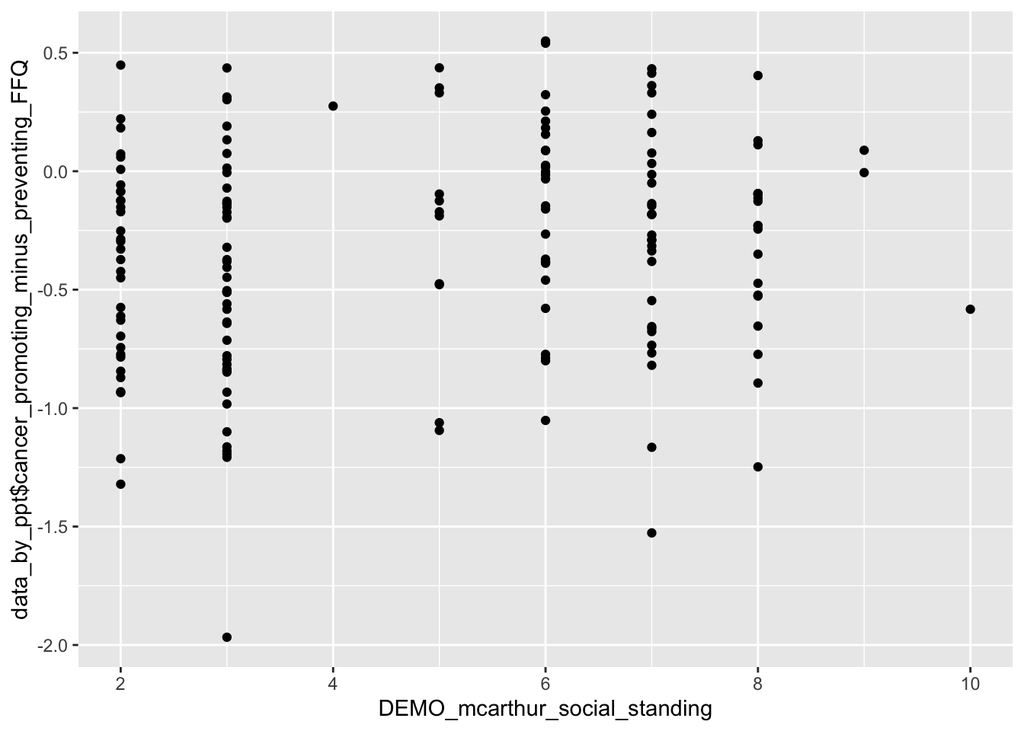

```r
ggplot(data_by_ppt,aes(DEMO_mcarthur_social_standing,data_by_ppt$cancer_promoting_minus_preventing_FFQ))+geom_point()
```

## Result

```r
View(correlation_df)
```

Now, let’s split these up into their families of predictions based on https://osf.io/gvus3:

```r
mcc <- function(cor_df){
  cor_df$p.value_adjusted <- p.adjust(cor_df$p.value,method="fdr")
  return(cor_df)
}
```

## Pre-registered predictions

### 2. Craving

```r
craving_ivs <- c("cancer_promoting_minus_preventing_craved_FCI")
craving_cors <- mcc(correlation_df[correlation_df$v2 %in% craving_ivs,])

craving_cors[c("v1","v2","n","p.value","p.value_adjusted")]
```

|  | v1 | v2 | n | p.value | p.value_adjusted |
| --- | --- | --- | --- | --- | --- |
| t | cancer_promoting_minus_preventing_FFQ | cancer_promoting_minus_preventing_craved_FCI | 200 | 5.231875e-18 | 1.046375e-17 |
| t16 | bf_1 | cancer_promoting_minus_preventing_craved_FCI | 164 | 4.584795e-01 | 4.584795e-01 |

the Food Craving Inventory is rleated to the Food Frequency Questionnaire but not body fat percentage.

### 3. Habit

```r
habit_ivs <- c("SRHI_sum","SRHI_healthy_minus_unhealthy")
habit_cors <- mcc(correlation_df[correlation_df$v2 %in% habit_ivs,])

habit_cors[c("v1","v2","n","p.value","p.value_adjusted")]
```

|  | v1 | v2 | n | p.value | p.value_adjusted |
| --- | --- | --- | --- | --- | --- |
| t5 | cancer_promoting_minus_preventing_FFQ | SRHI_sum | 187 | 6.209462e-02 | 1.241892e-01 |
| t6 | cancer_promoting_minus_preventing_FFQ | SRHI_healthy_minus_unhealthy | 187 | 2.052755e-11 | 8.211019e-11 |
| t21 | bf_1 | SRHI_sum | 157 | 3.302809e-01 | 4.403745e-01 |
| t22 | bf_1 | SRHI_healthy_minus_unhealthy | 157 | 6.900243e-01 | 6.900243e-01 |

The Self Report Habit Index is related to the Food Frequency Questionnaire but not body fat percentage.

overall habit score is not related to health outcomes.

```r
summary(lm(cancer_promoting_minus_preventing_FFQ~SRHI_healthy+SRHI_unhealthy,data_by_ppt))
```

```
##
## Call:
## lm(formula = cancer_promoting_minus_preventing_FFQ ~ SRHI_healthy +
##     SRHI_unhealthy, data = data_by_ppt)
##
## Residuals:
##      Min       1Q   Median       3Q      Max
## -1.12838 -0.27627  0.05617  0.31675  0.91160
##
## Coefficients:
##                 Estimate Std. Error t value Pr(>|t|)
## (Intercept)    -0.174643   0.202807  -0.861   0.3903
## SRHI_healthy   -0.014456   0.002862  -5.052 1.05e-06 ***
## SRHI_unhealthy  0.007268   0.003125   2.326   0.0211 *
## ---
## Signif. codes:  0 '***' 0.001 '**' 0.01 '*' 0.05 '.' 0.1 ' ' 1
##
## Residual standard error: 0.4017 on 184 degrees of freedom
##   (13 observations deleted due to missingness)
## Multiple R-squared:  0.2244, Adjusted R-squared:  0.216
## F-statistic: 26.62 on 2 and 184 DF,  p-value: 7.037e-11
```

```r
summary(lm(cancer_promoting_FFQ~SRHI_healthy+SRHI_unhealthy,data_by_ppt))
```

```
##
## Call:
## lm(formula = cancer_promoting_FFQ ~ SRHI_healthy + SRHI_unhealthy,
##     data = data_by_ppt)
##
## Residuals:
##      Min       1Q   Median       3Q      Max
## -0.62399 -0.22518 -0.02054  0.18347  1.00299
##
## Coefficients:
##                  Estimate Std. Error t value Pr(>|t|)
## (Intercept)     1.5158214  0.1537371   9.860  < 2e-16 ***
## SRHI_healthy   -0.0006826  0.0021692  -0.315 0.753369
## SRHI_unhealthy  0.0085980  0.0023690   3.629 0.000368 ***
## ---
## Signif. codes:  0 '***' 0.001 '**' 0.01 '*' 0.05 '.' 0.1 ' ' 1
##
## Residual standard error: 0.3045 on 184 degrees of freedom
##   (13 observations deleted due to missingness)
## Multiple R-squared:  0.0902, Adjusted R-squared:  0.08031
## F-statistic: 9.121 on 2 and 184 DF,  p-value: 0.0001671
```

```r
summary(lm(cancer_preventing_FFQ~SRHI_healthy+SRHI_unhealthy,data_by_ppt))
```

```
##
## Call:
## lm(formula = cancer_preventing_FFQ ~ SRHI_healthy + SRHI_unhealthy,
##     data = data_by_ppt)
##
## Residuals:
##     Min      1Q  Median      3Q     Max
## -0.8023 -0.2970 -0.0244  0.2722  1.3400
##
## Coefficients:
##                Estimate Std. Error t value Pr(>|t|)
## (Intercept)    1.690464   0.208289   8.116 6.70e-14 ***
## SRHI_healthy   0.013774   0.002939   4.687 5.39e-06 ***
## SRHI_unhealthy 0.001330   0.003210   0.414    0.679
## ---
## Signif. codes:  0 '***' 0.001 '**' 0.01 '*' 0.05 '.' 0.1 ' ' 1
##
## Residual standard error: 0.4126 on 184 degrees of freedom
##   (13 observations deleted due to missingness)
## Multiple R-squared:  0.1234, Adjusted R-squared:  0.1138
## F-statistic: 12.95 on 2 and 184 DF,  p-value: 5.493e-06
```

```r
cor(data_by_ppt[,c("cancer_promoting_FFQ","cancer_preventing_FFQ","SRHI_healthy","SRHI_unhealthy")],use = "pairwise.complete.obs")
```

```
##                       cancer_promoting_FFQ cancer_preventing_FFQ SRHI_healthy
## cancer_promoting_FFQ             1.0000000             0.2932806   -0.1583382
## cancer_preventing_FFQ            0.2932806             1.0000000    0.3500512
## SRHI_healthy                    -0.1583382             0.3500512    1.0000000
## SRHI_unhealthy                   0.2995201            -0.1367777   -0.4631672
##                       SRHI_unhealthy
## cancer_promoting_FFQ       0.2995201
## cancer_preventing_FFQ     -0.1367777
## SRHI_healthy              -0.4631672
## SRHI_unhealthy             1.0000000
```

```r
cor(data_by_ppt[,c("cancer_promoting_FFQ","cancer_preventing_FFQ","SRHI_healthy","SRHI_unhealthy", "bf_1")],use = "pairwise.complete.obs")
```

```
##                       cancer_promoting_FFQ cancer_preventing_FFQ SRHI_healthy
## cancer_promoting_FFQ             1.0000000            0.29328063  -0.15833821
## cancer_preventing_FFQ            0.2932806            1.00000000   0.35005119
## SRHI_healthy                    -0.1583382            0.35005119   1.00000000
## SRHI_unhealthy                   0.2995201           -0.13677766  -0.46316719
## bf_1                             0.2026761            0.08287582   0.01185807
##                       SRHI_unhealthy       bf_1
## cancer_promoting_FFQ      0.29952015 0.20267613
## cancer_preventing_FFQ    -0.13677766 0.08287582
## SRHI_healthy             -0.46316719 0.01185807
## SRHI_unhealthy            1.00000000 0.07127052
## bf_1                      0.07127052 1.00000000
```

```r
cor.test(data_by_ppt$SRHI_unhealthy,data_by_ppt$bf_1,use = "pairwise.complete.obs")
```

```
##
##  Pearson's product-moment correlation
##
## data:  data_by_ppt$SRHI_unhealthy and data_by_ppt$bf_1
## t = 0.88957, df = 155, p-value = 0.3751
## alternative hypothesis: true correlation is not equal to 0
## 95 percent confidence interval:
##  -0.0863314  0.2253924
## sample estimates:
##        cor
## 0.07127052
```

```r
cor.test(data_by_ppt$cancer_promoting_FFQ,data_by_ppt$bf_1,use = "pairwise.complete.obs")
```

```
##
##  Pearson's product-moment correlation
##
## data:  data_by_ppt$cancer_promoting_FFQ and data_by_ppt$bf_1
## t = 2.6343, df = 162, p-value = 0.009248
## alternative hypothesis: true correlation is not equal to 0
## 95 percent confidence interval:
##  0.05101063 0.34520395
## sample estimates:
##       cor
## 0.2026761
```

```r
cor.test(data_by_ppt$cancer_preventing_FFQ,data_by_ppt$bf_1,use = "pairwise.complete.obs")
```

```
##
##  Pearson's product-moment correlation
##
## data:  data_by_ppt$cancer_preventing_FFQ and data_by_ppt$bf_1
## t = 1.0585, df = 162, p-value = 0.2914
## alternative hypothesis: true correlation is not equal to 0
## 95 percent confidence interval:
##  -0.07127937  0.23316435
## sample estimates:
##        cor
## 0.08287582
```

```r
#OK nahhhh

cor.test(data_by_ppt$cancer_promoting_FFQ,data_by_ppt$SRHI_healthy,use = "pairwise.complete.obs")
```

```
##
##  Pearson's product-moment correlation
##
## data:  data_by_ppt$cancer_promoting_FFQ and data_by_ppt$SRHI_healthy
## t = -2.1811, df = 185, p-value = 0.03043
## alternative hypothesis: true correlation is not equal to 0
## 95 percent confidence interval:
##  -0.29512606 -0.01519008
## sample estimates:
##        cor
## -0.1583382
```

```r
cor.test(data_by_ppt$cancer_promoting_FFQ,data_by_ppt$SRHI_unhealthy,use = "pairwise.complete.obs")
```

```
##
##  Pearson's product-moment correlation
##
## data:  data_by_ppt$cancer_promoting_FFQ and data_by_ppt$SRHI_unhealthy
## t = 4.2699, df = 185, p-value = 3.121e-05
## alternative hypothesis: true correlation is not equal to 0
## 95 percent confidence interval:
##  0.1630339 0.4247577
## sample estimates:
##       cor
## 0.2995201
```

```r
cor.test(data_by_ppt$cancer_preventing_FFQ,data_by_ppt$SRHI_healthy,use = "pairwise.complete.obs")
```

```
##
##  Pearson's product-moment correlation
##
## data:  data_by_ppt$cancer_preventing_FFQ and data_by_ppt$SRHI_healthy
## t = 5.0828, df = 185, p-value = 9.059e-07
## alternative hypothesis: true correlation is not equal to 0
## 95 percent confidence interval:
##  0.2174821 0.4699394
## sample estimates:
##       cor
## 0.3500512
```

```r
cor.test(data_by_ppt$cancer_preventing_FFQ,data_by_ppt$SRHI_unhealthy,use = "pairwise.complete.obs")
```

```
##
##  Pearson's product-moment correlation
##
## data:  data_by_ppt$cancer_preventing_FFQ and data_by_ppt$SRHI_unhealthy
## t = -1.878, df = 185, p-value = 0.06195
## alternative hypothesis: true correlation is not equal to 0
## 95 percent confidence interval:
##  -0.274876015  0.006850039
## sample estimates:
##        cor
## -0.1367777
```

### 4. Inhibitory control and self regulation

```r
inhibitory_ivs <- c("TESQ_E","TRSQ",
         "BIS_11","BSCS",
         "EDM","RS")
inhibitory_cors <- mcc(correlation_df[correlation_df$v2 %in% inhibitory_ivs,])

inhibitory_cors[c("v1","v2","n","p.value","p.value_adjusted")]
```

|  | v1 | v2 | n | p.value | p.value_adjusted |
| --- | --- | --- | --- | --- | --- |
| t2 | cancer_promoting_minus_preventing_FFQ | EDM | 200 | 6.506407e-02 | 0.1951921998 |
| t3 | cancer_promoting_minus_preventing_FFQ | BSCS | 187 | 3.048941e-01 | 0.4573411074 |
| t7 | cancer_promoting_minus_preventing_FFQ | TESQ_E | 187 | 5.257824e-05 | 0.0006309389 |
| t8 | cancer_promoting_minus_preventing_FFQ | TRSQ | 187 | 2.328504e-01 | 0.3991721316 |
| t9 | cancer_promoting_minus_preventing_FFQ | RS | 200 | 4.929710e-01 | 0.6572946520 |
| t12 | cancer_promoting_minus_preventing_FFQ | BIS_11 | 200 | 3.218723e-02 | 0.1287489127 |
| t18 | bf_1 | EDM | 164 | 1.693063e-01 | 0.3386125093 |
| t19 | bf_1 | BSCS | 157 | 9.151200e-01 | 0.9151199933 |
| t23 | bf_1 | TESQ_E | 157 | 8.541998e-02 | 0.2050079604 |
| t24 | bf_1 | TRSQ | 157 | 7.995838e-01 | 0.8722731897 |

[output cut: 2 more lines]

```r
cor.test(data_by_ppt$cancer_promoting_FFQ,data_by_ppt$TESQ_E,use = "pairwise.complete.obs")
```

```
##
##  Pearson's product-moment correlation
##
## data:  data_by_ppt$cancer_promoting_FFQ and data_by_ppt$TESQ_E
## t = -0.92795, df = 185, p-value = 0.3546
## alternative hypothesis: true correlation is not equal to 0
## 95 percent confidence interval:
##  -0.20951320  0.07617095
## sample estimates:
##         cor
## -0.06806627
```

```r
cor.test(data_by_ppt$cancer_preventing_FFQ,data_by_ppt$TESQ_E,use = "pairwise.complete.obs")
```

```
##
##  Pearson's product-moment correlation
##
## data:  data_by_ppt$cancer_preventing_FFQ and data_by_ppt$TESQ_E
## t = 3.5442, df = 185, p-value = 0.0004986
## alternative hypothesis: true correlation is not equal to 0
## 95 percent confidence interval:
##  0.1127425 0.3818338
## sample estimates:
##       cor
## 0.2521564
```

The Tempest Self-Regulation Questionnaire for Eating is related to the Food Frequency Questionnaire.

It would be useful to examine the breakdown of the TESQ_E subscales and their relationship to the food frequency questionnaire.

There are some items that were significant when not adjusted for the multiple comparison, but not significant after adjusting:

- BIS_11 * FFQ
- Body Fat % * RS

It might be worth using these findings to guide neural investigation even as we acknowledge the evidence is not strong for them as main effects.

### 5. Socioeconomic

```r
ses_ivs <- c("ACES_sum","ses_aggregate","DEMO_mcarthur_social_standing","cSES")
ses_cors <- mcc(correlation_df[correlation_df$v2 %in% ses_ivs,])

ses_cors[c("v1","v2","n","p.value","p.value_adjusted","estimate")]
```

|  | v1 | v2 | n | p.value | p.value_adjusted | estimate |
| --- | --- | --- | --- | --- | --- | --- |
| t4 | cancer_promoting_minus_preventing_FFQ | ACES_sum | 155 | 0.74074838 | 0.9207583 | -0.02678758 |
| t13 | cancer_promoting_minus_preventing_FFQ | ses_aggregate | 150 | 0.09319619 | 0.3727848 | -0.13756960 |
| t14 | cancer_promoting_minus_preventing_FFQ | DEMO_mcarthur_social_standing | 167 | 0.02423770 | 0.1939016 | 0.17434059 |
| t15 | cancer_promoting_minus_preventing_FFQ | cSES | 111 | 0.26661379 | 0.7109701 | -0.10634595 |
| t20 | bf_1 | ACES_sum | 137 | 0.84397258 | 0.9207583 | 0.01696928 |
| t29 | bf_1 | ses_aggregate | 122 | 0.78650591 | 0.9207583 | 0.02477293 |
| t30 | bf_1 | DEMO_mcarthur_social_standing | 138 | 0.63780118 | 0.9207583 | -0.04042638 |
| t31 | bf_1 | cSES | 77 | 0.92075829 | 0.9207583 | -0.01152477 |

There is one relationship that is significant before but not after adjusting for multiple comparisons FFQ * the mcarthur ladder appears significant (p=0.02); however the estimate is in the reverse direction of that anticipated.

## Effects definitely worth a closer look

Craving: Food Craving Inventory is related to the Food Frequency Questionnaire

Habits: The Self-report habit index (healthy minus unhealthy contrast) is strongly related to the Food Frequency Questionnaire, although not to the BF%.

Inhibitory control: The Tempest Self-Regulation Questionnaire for Eating is related to the Food Frequency Questionnaire.

For each of these we can look at neural mediators. If we wanted to, we could tie this up into a single pretty powerful paper that demonstrates a trifecta of craving, habits, and inhibitory control all contributing to eating.

No relationships were found between socioeconomic measures and health outcomes.

### Investigating possible relationships with the values we found.

All of the variables that correlated with FFQ are very specifically food-related. Only explicitly-food-related versions of these constructs relate to FFQ, and none really relate to BF%.

I wonder how much *they* correlate with the more generic measures of their constructs? For instance, how does TESQ-E relate to other measures of inhibitory control?

```r
cor.test(data_by_ppt$TESQ_E,data_by_ppt$cancer_promoting_minus_preventing_FFQ)
```

```
##
##  Pearson's product-moment correlation
##
## data:  data_by_ppt$TESQ_E and data_by_ppt$cancer_promoting_minus_preventing_FFQ
## t = -4.1407, df = 185, p-value = 5.258e-05
## alternative hypothesis: true correlation is not equal to 0
## 95 percent confidence interval:
##  -0.4172880 -0.1541833
## sample estimates:
##        cor
## -0.2912332
```

```r
cor.test(data_by_ppt$TESQ_E,data_by_ppt$BIS_11)
```

```
##
##  Pearson's product-moment correlation
##
## data:  data_by_ppt$TESQ_E and data_by_ppt$BIS_11
## t = -0.7309, df = 185, p-value = 0.4658
## alternative hypothesis: true correlation is not equal to 0
## 95 percent confidence interval:
##  -0.19564647  0.09053067
## sample estimates:
##         cor
## -0.05365965
```

```r
cor.test(data_by_ppt$TESQ_E,data_by_ppt$BSCS)
```

```
##
##  Pearson's product-moment correlation
##
## data:  data_by_ppt$TESQ_E and data_by_ppt$BSCS
## t = 2.0356, df = 185, p-value = 0.04321
## alternative hypothesis: true correlation is not equal to 0
## 95 percent confidence interval:
##  0.004620243 0.285445978
## sample estimates:
##       cor
## 0.1480154
```

```r
cor.test(data_by_ppt$TESQ_E,data_by_ppt$BFI_conscientiousness)
```

```
##
##  Pearson's product-moment correlation
##
## data:  data_by_ppt$TESQ_E and data_by_ppt$BFI_conscientiousness
## t = 1.8217, df = 185, p-value = 0.07011
## alternative hypothesis: true correlation is not equal to 0
## 95 percent confidence interval:
##  -0.01095228  0.27107916
## sample estimates:
##       cor
## 0.1327496
```

```r
cor.test(data_by_ppt$TESQ_E,data_by_ppt$BFI_conscientiousness)
```

```
##
##  Pearson's product-moment correlation
##
## data:  data_by_ppt$TESQ_E and data_by_ppt$BFI_conscientiousness
## t = 1.8217, df = 185, p-value = 0.07011
## alternative hypothesis: true correlation is not equal to 0
## 95 percent confidence interval:
##  -0.01095228  0.27107916
## sample estimates:
##       cor
## 0.1327496
```

hmm–nothing very strong!

No other habit measures to look at but what about craving?

```r
cor.test(data_by_ppt$cancer_promoting_minus_preventing_craved_FCI,data_by_ppt$BIS_11)
```

```
##
##  Pearson's product-moment correlation
##
## data:  data_by_ppt$cancer_promoting_minus_preventing_craved_FCI and data_by_ppt$BIS_11
## t = 1.3068, df = 198, p-value = 0.1928
## alternative hypothesis: true correlation is not equal to 0
## 95 percent confidence interval:
##  -0.04687158  0.22828304
## sample estimates:
##        cor
## 0.09247078
```

## broad look at correlation plot

```r
vars_of_interest <- c("TESQ_E","cancer_promoting_minus_preventing_craved_FCI","SRHI_healthy_minus_unhealthy","cancer_promoting_minus_preventing_FFQ")

cor(data_by_ppt[,vars_of_interest],use = "pairwise.complete.obs")
```

```
##                                                  TESQ_E
## TESQ_E                                        1.0000000
## cancer_promoting_minus_preventing_craved_FCI -0.2956803
## SRHI_healthy_minus_unhealthy                  0.3861491
## cancer_promoting_minus_preventing_FFQ        -0.2912332
##                                              cancer_promoting_minus_preventing_craved_FCI
## TESQ_E                                                                         -0.2956803
## cancer_promoting_minus_preventing_craved_FCI                                    1.0000000
## SRHI_healthy_minus_unhealthy                                                   -0.5043152
## cancer_promoting_minus_preventing_FFQ                                           0.5614453
##                                              SRHI_healthy_minus_unhealthy
## TESQ_E                                                          0.3861491
## cancer_promoting_minus_preventing_craved_FCI                   -0.5043152
## SRHI_healthy_minus_unhealthy                                    1.0000000
## cancer_promoting_minus_preventing_FFQ                          -0.4648483
##                                              cancer_promoting_minus_preventing_FFQ
## TESQ_E                                                                  -0.2912332
## cancer_promoting_minus_preventing_craved_FCI                             0.5614453
## SRHI_healthy_minus_unhealthy                                            -0.4648483
## cancer_promoting_minus_preventing_FFQ                                    1.0000000
```

```r
print(summary(lm(cancer_promoting_minus_preventing_FFQ~TESQ_E+cancer_promoting_minus_preventing_craved_FCI+SRHI_healthy_minus_unhealthy,data_by_ppt)))
```

```
##
## Call:
## lm(formula = cancer_promoting_minus_preventing_FFQ ~ TESQ_E +
##     cancer_promoting_minus_preventing_craved_FCI + SRHI_healthy_minus_unhealthy,
##     data = data_by_ppt)
##
## Residuals:
##      Min       1Q   Median       3Q      Max
## -0.93711 -0.25045  0.02769  0.26330  0.81996
##
## Coefficients:
##                                               Estimate Std. Error t value
## (Intercept)                                  -0.330966   0.136914  -2.417
## TESQ_E                                       -0.002909   0.002327  -1.250
## cancer_promoting_minus_preventing_craved_FCI  0.301052   0.048234   6.241
## SRHI_healthy_minus_unhealthy                 -0.005182   0.001696  -3.055
##                                              Pr(>|t|)
## (Intercept)                                   0.01662 *
## TESQ_E                                        0.21290
## cancer_promoting_minus_preventing_craved_FCI 2.94e-09 ***
## SRHI_healthy_minus_unhealthy                  0.00259 **
## ---
## Signif. codes:  0 '***' 0.001 '**' 0.01 '*' 0.05 '.' 0.1 ' ' 1
##
## Residual standard error: 0.3643 on 183 degrees of freedom
##   (13 observations deleted due to missingness)
## Multiple R-squared:  0.3658, Adjusted R-squared:  0.3554
## F-statistic: 35.18 on 3 and 183 DF,  p-value: < 2.2e-16
```

```r
print(summary(lm(cancer_promoting_minus_preventing_FFQ~TESQ_E,data_by_ppt)))
```

```
##
## Call:
## lm(formula = cancer_promoting_minus_preventing_FFQ ~ TESQ_E,
##     data = data_by_ppt)
##
## Residuals:
##      Min       1Q   Median       3Q      Max
## -1.31643 -0.28736  0.05105  0.30263  0.87527
##
## Coefficients:
##              Estimate Std. Error t value Pr(>|t|)
## (Intercept)  0.244444   0.140435   1.741   0.0834 .
## TESQ_E      -0.010533   0.002544  -4.141 5.26e-05 ***
## ---
## Signif. codes:  0 '***' 0.001 '**' 0.01 '*' 0.05 '.' 0.1 ' ' 1
##
## Residual standard error: 0.4352 on 185 degrees of freedom
##   (13 observations deleted due to missingness)
## Multiple R-squared:  0.08482,    Adjusted R-squared:  0.07987
## F-statistic: 17.15 on 1 and 185 DF,  p-value: 5.258e-05
```

```r
print(summary(lm(cancer_promoting_minus_preventing_FFQ~cancer_promoting_minus_preventing_craved_FCI,data_by_ppt)))
```

```
##
## Call:
## lm(formula = cancer_promoting_minus_preventing_FFQ ~ cancer_promoting_minus_preventing_craved_FCI,
##     data = data_by_ppt)
##
## Residuals:
##      Min       1Q   Median       3Q      Max
## -0.94644 -0.25362  0.03318  0.28305  0.81375
##
## Coefficients:
##                                              Estimate Std. Error t value
## (Intercept)                                  -0.46761    0.02999 -15.593
## cancer_promoting_minus_preventing_craved_FCI  0.39807    0.04170   9.547
##                                              Pr(>|t|)
## (Intercept)                                    <2e-16 ***
## cancer_promoting_minus_preventing_craved_FCI   <2e-16 ***
## ---
## Signif. codes:  0 '***' 0.001 '**' 0.01 '*' 0.05 '.' 0.1 ' ' 1
##
## Residual standard error: 0.3773 on 198 degrees of freedom
## Multiple R-squared:  0.3152, Adjusted R-squared:  0.3118
## F-statistic: 91.14 on 1 and 198 DF,  p-value: < 2.2e-16
```

```r
print(summary(lm(cancer_promoting_minus_preventing_FFQ~SRHI_healthy_minus_unhealthy,data_by_ppt)))
```

```
##
## Call:
## lm(formula = cancer_promoting_minus_preventing_FFQ ~ SRHI_healthy_minus_unhealthy,
##     data = data_by_ppt)
##
## Residuals:
##      Min       1Q   Median       3Q      Max
## -1.10237 -0.28519  0.03912  0.29586  0.87986
##
## Coefficients:
##                               Estimate Std. Error t value Pr(>|t|)
## (Intercept)                  -0.455042   0.034857 -13.055  < 2e-16 ***
## SRHI_healthy_minus_unhealthy -0.011078   0.001551  -7.141 2.05e-11 ***
## ---
## Signif. codes:  0 '***' 0.001 '**' 0.01 '*' 0.05 '.' 0.1 ' ' 1
##
## Residual standard error: 0.4028 on 185 degrees of freedom
##   (13 observations deleted due to missingness)
## Multiple R-squared:  0.2161, Adjusted R-squared:  0.2118
## F-statistic: 50.99 on 1 and 185 DF,  p-value: 2.053e-11
```

```r
null_rows <- apply(is.na(data_by_ppt[,vars_of_interest]),1,any)
print(anova(
  lm(cancer_promoting_minus_preventing_FFQ~cancer_promoting_minus_preventing_craved_FCI,data_by_ppt[null_rows==FALSE,]),
lm(cancer_promoting_minus_preventing_FFQ~TESQ_E+cancer_promoting_minus_preventing_craved_FCI+SRHI_healthy_minus_unhealthy,data_by_ppt[null_rows==FALSE,])
))
```

```
## Analysis of Variance Table
##
## Model 1: cancer_promoting_minus_preventing_FFQ ~ cancer_promoting_minus_preventing_craved_FCI
## Model 2: cancer_promoting_minus_preventing_FFQ ~ TESQ_E + cancer_promoting_minus_preventing_craved_FCI +
##     SRHI_healthy_minus_unhealthy
##   Res.Df    RSS Df Sum of Sq      F   Pr(>F)
## 1    185 26.174
## 2    183 24.281  2    1.8933 7.1346 0.001038 **
## ---
## Signif. codes:  0 '***' 0.001 '**' 0.01 '*' 0.05 '.' 0.1 ' ' 1
```

```r
print(anova(
  lm(cancer_promoting_minus_preventing_FFQ~cancer_promoting_minus_preventing_craved_FCI+SRHI_healthy_minus_unhealthy,data_by_ppt[null_rows==FALSE,]),
lm(cancer_promoting_minus_preventing_FFQ~TESQ_E+cancer_promoting_minus_preventing_craved_FCI+SRHI_healthy_minus_unhealthy,data_by_ppt[null_rows==FALSE,])
))
```

```
## Analysis of Variance Table
##
## Model 1: cancer_promoting_minus_preventing_FFQ ~ cancer_promoting_minus_preventing_craved_FCI +
##     SRHI_healthy_minus_unhealthy
## Model 2: cancer_promoting_minus_preventing_FFQ ~ TESQ_E + cancer_promoting_minus_preventing_craved_FCI +
##     SRHI_healthy_minus_unhealthy
##   Res.Df    RSS Df Sum of Sq      F Pr(>F)
## 1    184 24.488
## 2    183 24.281  1   0.20732 1.5625 0.2129
```

So…FCI alone predicts 31% of variance of FFQ; all three combined predicts 35% of variance; including TESQ_E in the model does NOT improve model fit, though the SRHI does.

So: SHRI has some extra predictive power.

We might also extend this with an ML approach: apply a learning approach to classify subjects into groups. Can’t expect this to give us too much because there’ll only be ~150 subjects or so in the model.

let’s leave this until we have the behavioral data but I will get to it!

## Supplementary analysis

Of the above I have already examined one outcome, Responses to Failure Scale. This appears to be a fairly robust finding:

```r
rtfs_ivs <- c("RTFS_factor_1","RTFS_factor_2")
rtfs_cors <- mcc(correlation_df[correlation_df$v2 %in% rtfs_ivs,])

rtfs_cors[c("v1","v2","n","p.value","p.value_adjusted","estimate")]
```

|  | v1 | v2 | n | p.value | p.value_adjusted | estimate |
| --- | --- | --- | --- | --- | --- | --- |
| t10 | cancer_promoting_minus_preventing_FFQ | RTFS_factor_1 | 159 | 0.006634952 | 0.02653981 | 0.21446557 |
| t11 | cancer_promoting_minus_preventing_FFQ | RTFS_factor_2 | 162 | 0.871464214 | 0.87146421 | -0.01281080 |
| t26 | bf_1 | RTFS_factor_1 | 125 | 0.477988677 | 0.87146421 | 0.06404149 |
| t27 | bf_1 | RTFS_factor_2 | 129 | 0.779243101 | 0.87146421 | 0.02491823 |

It isn’t clear that it fits into any of the above categories.

There are additional items we might examine:

- Big Five
- Planfulness
- Regulatory Mode Questionnaire
- Perceived Competence Scale
- Mother and/or father education
- All the individual levels of income that we only tested in aggregate for this analysis ((a) zipcode typical income, (b) total household income, (c) household per capita income, (d) education level)

Seems cheeky to go and do a *second* pre-registration for these so I recommend just going ahead with a further analysis; however I want to seek input from others first.

Also, what about considering more granular measures in the FFQ and FCI?